# Staph genome size distribuiton

```r
library(tidyr)
```

[output not shown]

```r
gold_samps <- get_public_samples() %>% filter(rank == 3)
contigs <- get_assembly_stats(gold_samps$sample_id)
```

#### plasmids

(local path will vary) These ae lists of contigs called as plasmid by SPAdes baed on coverage and other metrics

```r
plas_table <- read_feather("/Volumes/DATA_2TB/Dropbox/Staphopia_resources/staph_genome_views/staphopia-plasmids.feather") %>%
  group_by(sample_id) %>% summarise(plasmid_len = sum(length),plas_contigs = n())
```

#### create useful merged gold data table

```r
merged_tables <- inner_join(contigs,gold_samps, by = "sample_id") %>%
  select(sample_id,st,total_contig,total_contig_length,percent_contigs_greater_1k,l50_contig_count,n50_contig_length)
gold_summary <-inner_join(merged_tables,plas_table,by="sample_id")
```

```r
mean(gold_summary$total_contig_length)
```

```
[1] 2829361
```

```r
sd(gold_summary$total_contig_length)
```

```
[1] 107390.1
```

How does the proportion of small assemblies vary by contig length?

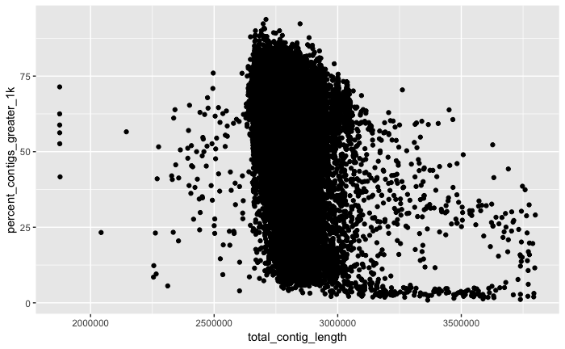

```r
p <- ggplot(gold_summary, aes(x= total_contig_length, y = percent_contigs_greater_1k)) + geom_point()
p
```

Note the hard line at about 2.7 Mbp? Also the group of strains with total_length greater than ~ 2.8Mbp but %contigs less than 10% Interesting set of strains seem to all have genomes of ~ 1.8 Mbp.

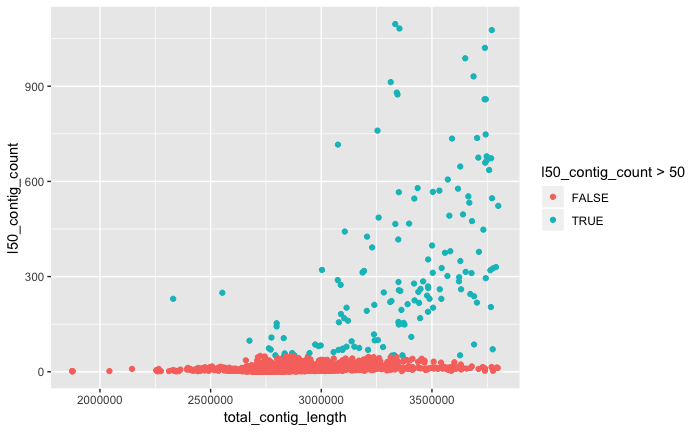

```r
p <- ggplot(gold_summary, aes(x= total_contig_length, y = l50_contig_count, color=l50_contig_count > 50)) + geom_point()
p
```

The l50 contig count increases with total size (above 2.75 Mb) this is probably a factor of low quality (or maybe higher levels of transposon)

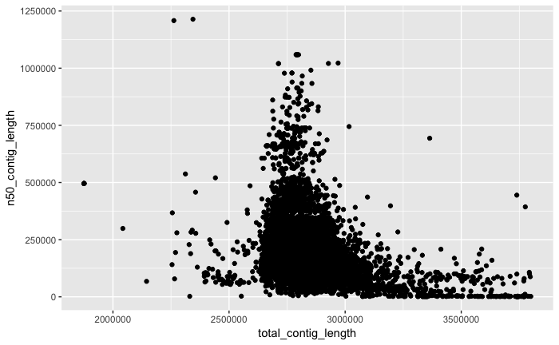

```r
p <- ggplot(gold_summary, aes(x= total_contig_length, y = n50_contig_length)) + geom_point()
p
```

```r
filter(gold_summary,total_contig_length < 2630000) %>%
  select(st) %>%
  table()
```

```
.
  0  22 225 957
 96   1   1   1
```

`r`r p <- ggplot(gold_summary,aes(x=total_contig_length, color = (st==239))) + geom_histogram(binwidth=10000) p

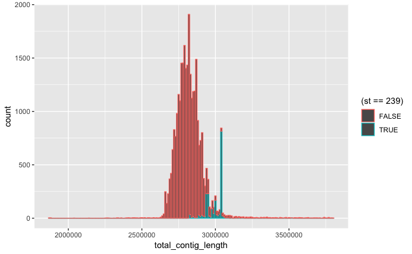

Interesting set of peaks, especially the one over 3,000,000, which is mostly ST239

`r`r p <- ggplot(gold_summary,aes(x=total_contig_length, color = (st==0))) + geom_histogram(binwidth=10000) p

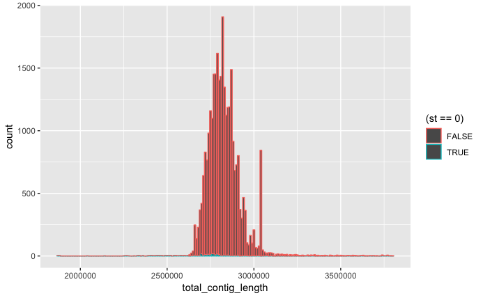

`r`r p <- ggplot(gold_summary, aes(x= total_contig, y = plasmid_len, color=l50_contig_count > 50)) + geom_point() p

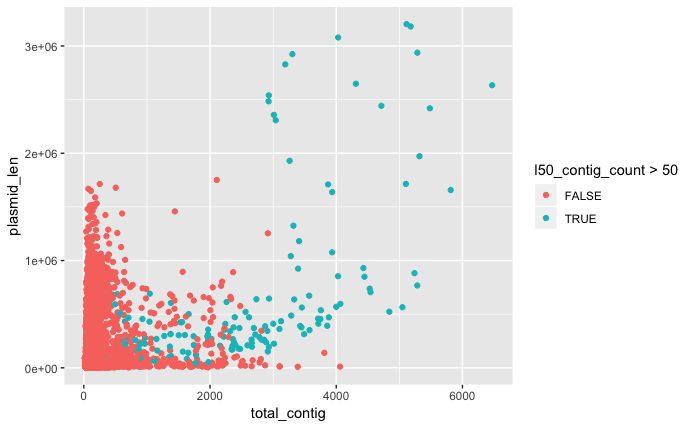

`r`r p <- ggplot(gold_summary,aes(x=total_contig_length-plasmid_len)) + geom_histogram(binwidth=10000) p

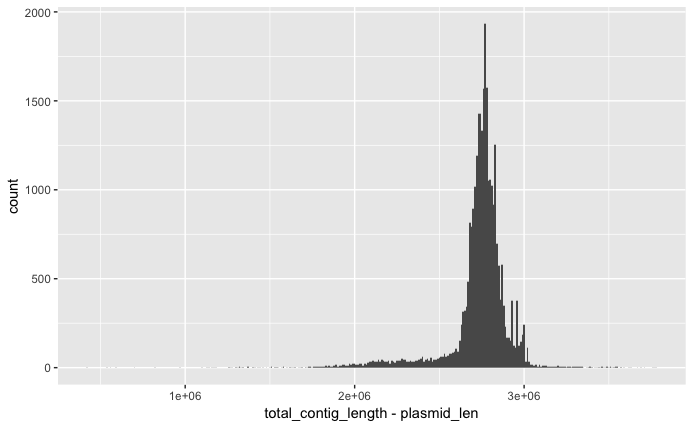

`r`r table(cut(gold_summary$total_contig_length, breaks = 100))

```
(1.87e+06,1.89e+06] (1.89e+06,1.91e+06] (1.91e+06,1.93e+06] (1.93e+06,1.95e+06]
                  6                   0                   0                   0
(1.95e+06,1.97e+06] (1.97e+06,1.99e+06] (1.99e+06,2.01e+06] (2.01e+06,2.03e+06]
                  0                   0                   0                   0
(2.03e+06,2.05e+06] (2.05e+06,2.07e+06] (2.07e+06,2.09e+06] (2.09e+06,2.11e+06]
                  1                   0                   0                   0
(2.11e+06,2.13e+06] (2.13e+06,2.14e+06] (2.14e+06,2.16e+06] (2.16e+06,2.18e+06]
                  0                   0                   1                   0
 (2.18e+06,2.2e+06]  (2.2e+06,2.22e+06] (2.22e+06,2.24e+06] (2.24e+06,2.26e+06]
                  0                   0                   0                   2
(2.26e+06,2.28e+06]  (2.28e+06,2.3e+06]  (2.3e+06,2.32e+06] (2.32e+06,2.34e+06]
                  4                   0                   1                   4
(2.34e+06,2.36e+06] (2.36e+06,2.38e+06] (2.38e+06,2.39e+06] (2.39e+06,2.41e+06]
                  3                   2                   2                   7
(2.41e+06,2.43e+06] (2.43e+06,2.45e+06] (2.45e+06,2.47e+06] (2.47e+06,2.49e+06]
                  4                   6                   7                   3
(2.49e+06,2.51e+06] (2.51e+06,2.53e+06] (2.53e+06,2.55e+06] (2.55e+06,2.57e+06]
                 11                   5                   5                   6
(2.57e+06,2.59e+06] (2.59e+06,2.61e+06] (2.61e+06,2.63e+06] (2.63e+06,2.64e+06]
                  7                   5                   6                  32
(2.64e+06,2.66e+06] (2.66e+06,2.68e+06]  (2.68e+06,2.7e+06]  (2.7e+06,2.72e+06]
                240                 383                 708                1314
(2.72e+06,2.74e+06] (2.74e+06,2.76e+06] (2.76e+06,2.78e+06]  (2.78e+06,2.8e+06]
               1563                2225                2663                2862
 (2.8e+06,2.82e+06] (2.82e+06,2.84e+06] (2.84e+06,2.86e+06] (2.86e+06,2.88e+06]
               3148                2676                2236                2573
(2.88e+06,2.89e+06] (2.89e+06,2.91e+06] (2.91e+06,2.93e+06] (2.93e+06,2.95e+06]
               1534                1503                 660                 840
(2.95e+06,2.97e+06] (2.97e+06,2.99e+06] (2.99e+06,3.01e+06] (3.01e+06,3.03e+06]
                199                 262                 281                 114
(3.03e+06,3.05e+06] (3.05e+06,3.07e+06] (3.07e+06,3.09e+06] (3.09e+06,3.11e+06]
                915                  67                  51                  45
(3.11e+06,3.13e+06] (3.13e+06,3.15e+06] (3.15e+06,3.16e+06] (3.16e+06,3.18e+06]
                 22                  29                  24                  22
 (3.18e+06,3.2e+06]  (3.2e+06,3.22e+06] (3.22e+06,3.24e+06] (3.24e+06,3.26e+06]
                 17                  18                  21                  15
(3.26e+06,3.28e+06]  (3.28e+06,3.3e+06]  (3.3e+06,3.32e+06] (3.32e+06,3.34e+06]
                  9                  11                  10                  13
(3.34e+06,3.36e+06] (3.36e+06,3.38e+06]  (3.38e+06,3.4e+06]  (3.4e+06,3.41e+06]
                 15                  11                   7                  10
(3.41e+06,3.43e+06] (3.43e+06,3.45e+06] (3.45e+06,3.47e+06] (3.47e+06,3.49e+06]
                  4                  11                   6                   9
(3.49e+06,3.51e+06] (3.51e+06,3.53e+06] (3.53e+06,3.55e+06] (3.55e+06,3.57e+06]
                  9                   5                   7                   8
(3.57e+06,3.59e+06] (3.59e+06,3.61e+06] (3.61e+06,3.63e+06] (3.63e+06,3.65e+06]
                 10                   4                   7                   8
(3.65e+06,3.66e+06] (3.66e+06,3.68e+06]  (3.68e+06,3.7e+06]  (3.7e+06,3.72e+06]
                  4                   6                   3                   5
(3.72e+06,3.74e+06] (3.74e+06,3.76e+06] (3.76e+06,3.78e+06]  (3.78e+06,3.8e+06]
                  7                   6                  10                   5
```

It looks like the inflexion point for the bottom limit of S. aureus genome size is 2.63 Mb. On the other side, maybe 3.11 Mb

Start with looking at the the small ones

```r
under2.63Mb <- gold_summary %>% filter(total_contig_length < 2630000)
under2.63Mb_meta <- get_metadata(under2.63Mb$sample_id)
table(under2.63Mb$st)
```

```
  0  22 225 957
 96   1   1   1
```

```r
under2.63Mb_scccmec <- get_sccmec_type(under2.63Mb$sample_id)
summary(under2.63Mb_scccmec)
```

```
   sample_id         I               II             III              IV              V               VI             VII
 Min.   :  379   Mode :logical   Mode :logical   Mode :logical   Mode :logical   Mode :logical   Mode :logical   Mode :logical
 1st Qu.: 2394   FALSE:99        FALSE:99        FALSE:99        FALSE:85        FALSE:94        FALSE:99        FALSE:94
 Median : 2818                                                   TRUE :14        TRUE :5                         TRUE :5
 Mean   : 9939
 3rd Qu.:13330
 Max.   :40052
    VIII             IX             meca
 Mode :logical   Mode :logical   Mode :logical
 FALSE:99        FALSE:99        FALSE:56
                                 TRUE :43
```

Now get the large contigs in many pieces

`r`r over3.11_small <- gold_summary %>% filter(total_contig_length > 3110000) %>% filter(l50_contig_count > 50) over3.11_small_meta <- get_metadata(over3.11_small$sample_id) table(over3.11_small$st)

```
   0    1    5    6    8   15   22   25   30   36   45   59   72   78   81   97  101  105  121
  16    3   10    1   13    4   10    5   11    2    9    4    1    1    1    3    3    1    1
 130  225  228  361  398  425  461 1607 1850 1863 2160 3054 3213
   2    1    1    1    3    1    2    1    1    1    1    1    1
```

These strains are more diverse - no obvious common thread

`r`r over3.11_large <- gold_summary %>% filter(total_contig_length > 3110000) %>% filter(l50_contig_count <= 49) over3.11_large_meta <- get_metadata(over3.11_large$sample_id) table(over3.11_large$st)

```
   0    1    5    6    7    8    9   15   20   22   25   26   30   34   36   39   45   72   88
  12    1   40    1    2   23    1    2    1   30    4    1   17    1   10    3   12    1    1
  93   97  101  105  111  125  130  133  146  152  180  225  228  231  239  241  243  250  254
   3    1    1   13    1    1    6    1    1    2    1    1    2    1   16    2    1    1    1
 256  368  398  425  521  609  772 1066 1245 1564 1764 2198 2729 2866 2876 3106 3110 3349
   1    1   16    4    1    7    5    1    1    1    1    1    1    1    1    1    1    1
```

Nothing stands out in these large samples

## t-tests using dplyr

`r`r all_conlens <- gold_summary$total_contig_length pvals <- merged_tables %>% group_by(st) %>% summarise(conlens = list(total_contig_length), mean_con_length = mean(total_contig_length), sd_contig_length = sd(total_contig_length)) %>% filter(lengths(conlens) > 100) %>% rowwise() %>% mutate(p_value = t.test(unlist(conlens), !(all_conlens %in% unlist(conlens)))$p.value)

## cgMLST Check that these maybe have other S. aureus STs? Get a list of gold St=0 and look st the cgmlst profiles

`r`r gold_st0 <- filter(gold_summary,st == 0) gold_st0_cgmlst <- get_cgmlst(gold_st0$sample_id)

How many alleles are missing?

`r`r rowSums(gold_st0_cgmlst == 0) rowSums(is.na(gold_st0_cgmlst))

Now see if all the small genomes are similar to each other

`r`r under_2.63Mb_cgmlt <- filter(gold_st0_cgmlst,sample_id %in% under2.63Mb$sample_id) under2.63Mb_cgmlst_distance <- cgmlst_distance(under_2.63Mb_cgmlt)

```
[1] \Working on 10 of 108\
[1] \Working on 20 of 108\
[1] \Working on 30 of 108\
[1] \Working on 40 of 108\
[1] \Working on 50 of 108\
[1] \Working on 60 of 108\
[1] \Working on 70 of 108\
[1] \Working on 80 of 108\
[1] \Working on 90 of 108\
[1] \Working on 100 of 108\
```

`r`r plot(hclust(as.dist(under2.63Mb_cgmlst_distance)), cex = 0.5)

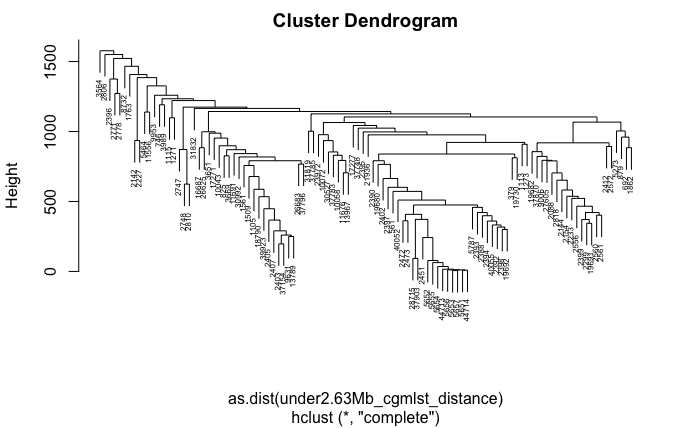

## Short genomes Blast analysis

blastn -query short_staph.fasta -task “megablast” -outfmt 6 -o short_staph_vs_FPR.results -db /Volumes/DATA_2TB/Dropbox/Staphopia_resources/genoplotR_genomes/USA300_FPR3757.gbk.fna

3. Filter for top hits

awk ‘! a[$1]++’ short_staph_vs_FPR.results | sed ‘s/|/ /g’ > short_staph_vs_FPR.results_best_hits

```r
short_genome_blast <- read.table("/Users/timothyread/Documents/short_staph/short_staph_vs_FPR.results_best_hits",header = F, stringsAsFactors = F)
short_genome_blast %>% group_by(V1) %>%
  summarise(total_hit_len = sum(V6)) %>%
  filter(total_hit_len > 1500000)
```

| V1 | total_hit_len |
| --- | --- |
| 17745 | 2314358 |

In other words , only 17745 looks like it might be Staph aureus. It actually has a ST type - ST225. The others - probably not S. aureus. This is why we need mash.

## PLASMIDS

`r`r p <- ggplot(gold_summary,aes(x=plasmid_len)) + geom_histogram(binwidth=100000) p

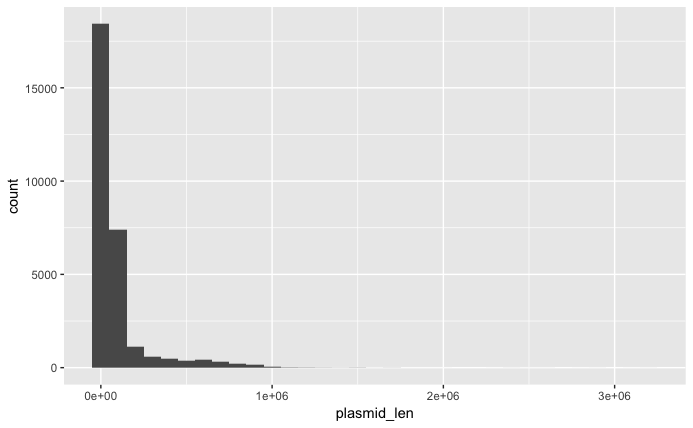

Ok - there are some projects with plasmid length > 500,000. This is definately a symptom of something amiss with the data.

`r`r library(ggfortify) df <- gold_summary[c(3, 4, 5, 6,7,8,9)] autoplot(prcomp(df))

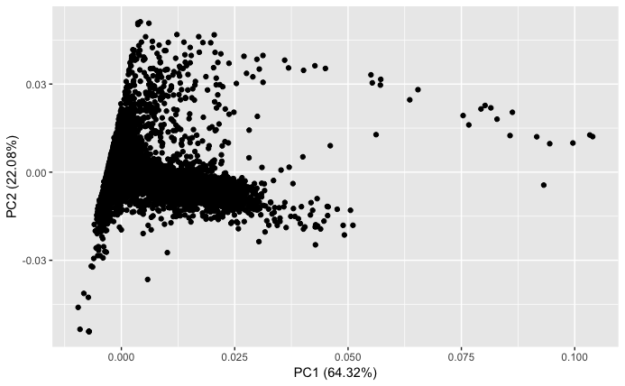

## SOME THOUGHTS

1. The SPAdes plasmid desingation is an indirect measure of quality, I think. Tends to happen more in lower quality genomes.
2. Most genomes are the “correct” size and assemble into a relatively small number of contigs.
3. There seem to be a diverse group of small genomes

## QUESTIONS TODO

1. Detailed analysis of small and large genomes. Are they associated with particular clades?
2. Are some clades larger/smaller than others?
3. How well do plasmid designations predict total genome size (phage?)